# Economic Data 2024 - Labs

Week 11

*Aims*: Data cleaning, applying functions by groups, libraries and data formats.

Your country depends on the timing of your lab session:

- Group 1: Tuesday 9:00 to 11:00: Greece
- Group 2: Tuesday 11:00 to 13:00: Finland
- Group 3: Tuesday 16:00 to 18:00: Spain
- Group 4: Wednesday 09:00 to 11:00: Slovenia
- Group 5: Wednesday 11:00 to 13:00: France

## Part 1

Work on mini projects 1 to 4.

## Part 2 (optional)

In this exercise, will explore the evolution of real GDP per capita using the Penn World Tables (you can read more about the Penn World Tables [here](https://www.economist.com/finance-and-economics/2024/11/07/big-macs-strawberry-jam-and-the-wealth-of-nations)). The latest version of the data is available [here](https://www.rug.nl/ggdc/productivity/pwt/?lang=en).

We will explore if poor countries grew faster than rich countries over the 1960 to 2015 period. Economists refer to this phenomenon as *absolute convergence* since it suggests that economic growth will erode cross-national income differences. To do this, we will compare the growth rates of countries with different levels of GDP per capita in 1960.

To solve the exercise, go through the following steps.

- Download the data and clean the dataset.
- Create a new column in your data containing the GDP per capita.
- Create a new column that denotes the GDP per capita in 1960. **Hint**: `group_by(country) %>% mutate(gdp_1960 = ifelse(year == 1960, gdppc, 0), gdp_1960 = max(gdp_1960))`.
- Keep only data for 2015. Remove any rows for which the column containing the GDP per capita in 1960 is missing.
- Calculate the average annual rate of growth between 1960 and 2015 for every country.
- Construct the plot below.

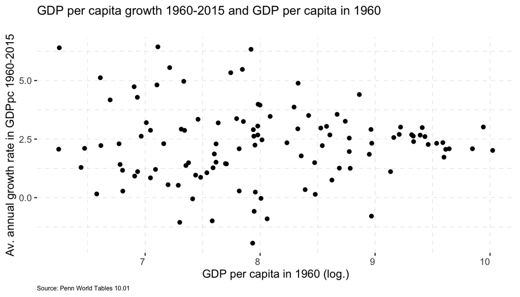

- Is there compelling evidence for *absolute convergence* in your opinion?

Motivated by models of economic growth, economists developed the concept of *conditional convergence*. This theory argues that countries with similar characteristics will experience convergence in income. To examine this, we can look at the association between initial income and rates of economic growth by continent.

- Create a new column that denotes the continent of each country. **Hint**: Use the library `countrycode` and the function `mutate(continent = countrycode(sourcevar = country, origin = "country.name", destination = "continent"))`.
- Construct the chart below. **Hint**: Use `ggplot` and `facet_wrap(~continent)`.

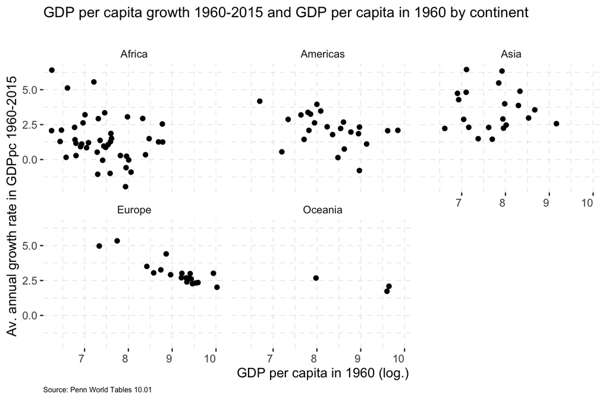

- Is there evidence of absolute convergence for any of the continents?
- Keep only observations on European countries.
- Construct a column that denotes the different quantiles of GDP per capita in 1960. **Hint**: Use `mutate(decile = ntile(gdp_1960, 5))`.
- Calculate the average rate of growth by quantile between 1960 and 2015. **Hint**: `group_by(decile) %>% summarise(l_gdp_1960 = mean(log(gdp_1960), na.rm = T), gdppc_g = mean(gdppc_g, na.rm = T))`.
- Construct the following plot.

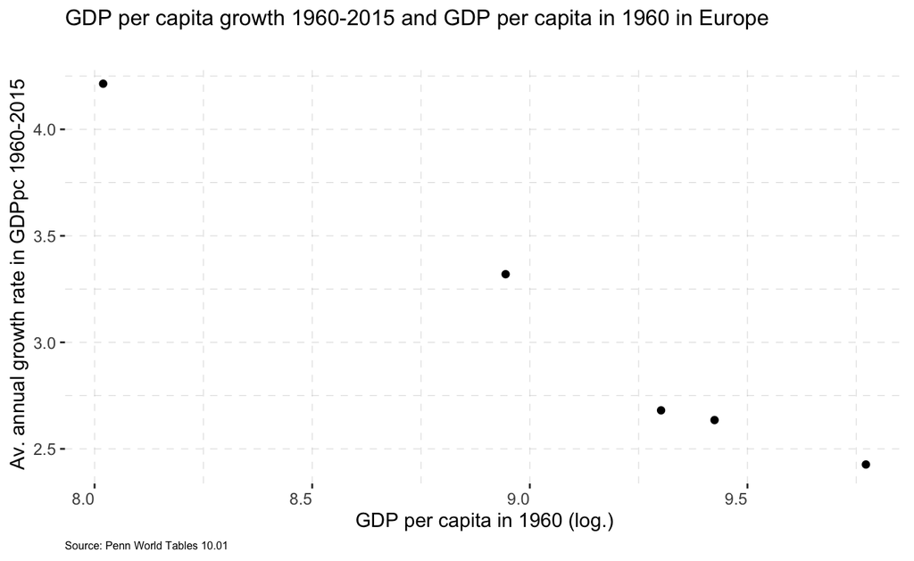

- Is there evidence of *absolute convergence* in European countries over the period?